# @MPRA package vignette

Dandi Qiao

2019-01-30

# 1 Introduction

The analysis toolset for MPRA data (@MPRA) includes functions for simulating and analyzing MPRA data, and for power calculations of MPRA experiments. This tutorial briefly introduces the functions provided by the @MPRA package, using the example data included in the package.

We can load the library using:

```r
library(atMPRA)
```

We can do a quick power calculation:

```r
nsim = 10
ntag = 10

result = getPower(nsim = nsim, ntag = ntag, nrepIn = 3, nrepOut = 3,
    slope = c(rep(1, ntag * nsim), rep(2, ntag * nsim)), method = c("MW",
        "mpra_lm"), scenario = "fixTotalDepth")
```

```
## [1] 0.7
```

```r
result$Power
```

```
## [1] 0.7
```

# 2 Data available in the package

The estimated distributional parameters of the MPRA data (GSE70531 in GEO database) was obtained using the `estimateMPRA` function in this package. The basic parameters include \ `inputProp`: The proportion of counts per tag among all tags in the library\ `transEff`: The distribution of transfection efficiencies (normalized RNA/DNA ratio) across tags\ `dispFunc_input`: The dispersion function of the input tag counts across replicates as a function of the mean \ `dispFunc_output`: The dispersion function of the output tag counts across replicates as a function of the mean\ \

We assume that the tag counts across replicates follow a Negative Binomial distribution with mean $\mu$ and dispersion $\sigma^2$. Then the variance is $\mu + \sigma^2\mu^2$.

However, it is observed that the dispersion parameter is not constant in RNA-Seq data. In DESeq2, it was assumed that:
$$log(\sigma^2) \sim N(log(a+b/\mu), \sigma_d^2)$$
We will use the dispersion function estimated by DESeq2 to generate count data here.

The estimation parameters for GSE70531 was done using the `estimateMPRA` function which used DESeq2 package. This distribution will be the default distribution for simulating MPRA data in this package if not specified otherwise. The data is loaded with the package automatically.

```r
GSE70531_params
```

```
## $dispFunc_input
## function (means)
## exp(predict(fit, data.frame(logMeans = log(means))))
## <bytecode: 0x7ffca27bfba8>
## <environment: 0x7ffc97d17e30>
## attr(,"fitType")
## [1] "local"
## attr(,"varLogDispEsts")
## [1] 0.4812829
## attr(,"dispPriorVar")
## [1] 0.25
##
## $dispFunc_output
## function (q)
## coefs[1] + coefs[2]/q
## <bytecode: 0x7ffc847bd588>
## <environment: 0x7ffca27bc1c0>
## attr(,"coefficients")
## asymptDisp  extraPois
##  0.5183263 12.7233435
## attr(,"fitType")
## [1] "parametric"
## attr(,"varLogDispEsts")
## [1] 0.8172103
## attr(,"dispPriorVar")
## [1] 0.3268525
##
## $inputProp
## function (v)
## .approxfun(x, y, v, method, yleft, yright, f)
## <bytecode: 0x7ffc847bed60>
## <environment: 0x7ffc847bdda0>
##
## $transEff
## function (v)
## .approxfun(x, y, v, method, yleft, yright, f)
## <bytecode: 0x7ffc847ac820>
## <environment: 0x7ffc847ab898>
##
## $sizeFactor_input
## K562_minP_DNA1 K562_minP_DNA2
##      1.2060454      0.8291562
##
## $sizeFactor_output
## K562_CTRL_minP_RNA1 K562_CTRL_minP_RNA2 K562_CTRL_minP_RNA3
##           0.6613516           0.4404059           1.4904598
## K562_CTRL_minP_RNA4 K562_CTRL_minP_RNA5 K562_CTRL_minP_RNA6
##           1.2337356           1.8488591           1.3372992
```

The input proportions are usually very skewed due to cloning and PCR.

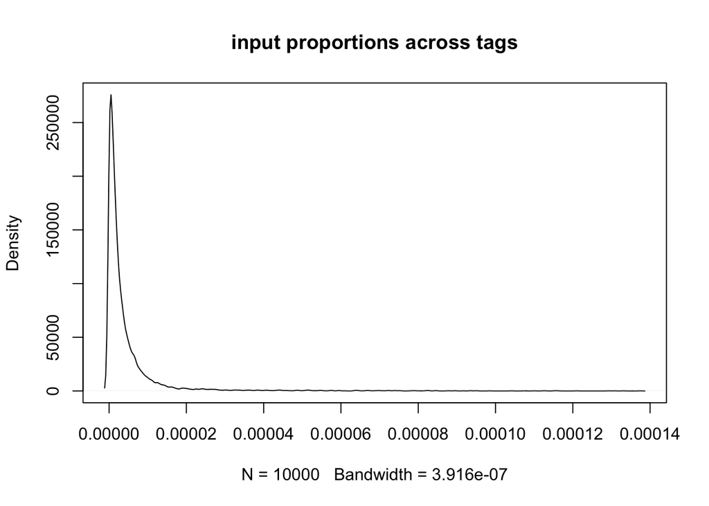

```r
plot(density(GSE70531_params[[3]](runif(10000))), main="input proportions across tags")
```

The transfection efficiency distribution for GSE70531 looks like this:

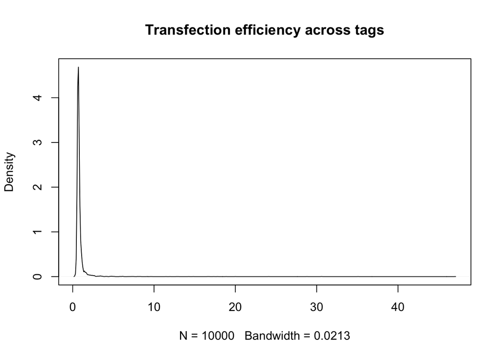

```r
plot(density(GSE70531_params[[4]](runif(10000))), main="Transfection efficiency across tags")
```

# 3 Functions

## 3.1 Simulating MPRA data

There are multiple ways to simulate MPRA data in this package:

1. Simulating MPRA data using default distribution.
2. Simulating MPRA data using estimated distributions from observed data
3. Simulating MPRA data by specifying parameters in the model.

The parameters for simulating a MPRA dataset includes:

1. number of SNPs in the data (`nsim`)
2. number of tags per SNP (`ntag`)
3. number of replicates in the input and output (`nrepIn`, `nrepOut`)
4. RNA/DNA ratio for all tags (`slope`)
5. Total depth for one replicate (`fixTotalD`) or mean depth per tag (`fixMeanD`)

### 3.1.1 Simulating MPRA data using estimated distributions from observed data

```r
totalDepth = 2e+05

ntag = 10

nsim = 10

nrepIn = 5

nrepOut = 5

inputProp = GSE70531_params[[3]](runif(ntag * nsim * 2))

slopel = GSE70531_params[[4]](runif(nsim * 2))

inputDispFunc = GSE70531_params[[1]]

outputDispFunc = GSE70531_params[[2]]

slope = rep(slopel, each = ntag)

datt = sim_fixDepth(inputProp, ntag, nsim, nrepIn, nrepOut, slope,
    inputDispFunc = inputDispFunc, outputDispFunc = outputDispFunc,
    sampleDepth = totalDepth)

datt[1:10, ]
```

```
##    allele simN input_rep1 input_rep2 input_rep3 input_rep4 input_rep5
## 1     Ref    1        238        283        322        207        264
## 2     Ref    1        215        199        194        225        266
## 3     Ref    1       2449       2453       2434       2461       2476
## 4     Ref    1        108         88        165        152        109
## 5     Ref    1       1862       1629       1911       1823       2009
## 6     Ref    1        130        131        140         99        113
## 7     Ref    1         15         16         26         24         23
## 8     Ref    1       1267       1194       1254       1215       1222
## 9     Ref    1         26         14         35         18         14
## 10    Ref    1        877        990        890        840        961
##    output_rep1 output_rep2 output_rep3 output_rep4 output_rep5
## 1          175         342          66         570         170
## 2           85         386          86         178         174
## 3         7959        2162        1340        6245        1044
## 4           80          15         234         268          60
## 5         1029         804        1892        2027         278
## 6          202          52         186         161         105
## 7            0          11          15          30           0
## 8           80         973         777          88        1166
## 9           44          32           2           0          19
## 10         269          96         497         775        1166
```

If we would like to simulate data based on an observed MPRA dataset, we can estimate the parameters using the function `estimateMPRA`.

```r
rnaCol=8

new_params=estimateMPRA(datt, nrepIn, rnaCol, nrepOut, nsim, ntag)

new_params
```

```
## $dispFunc_input
## function (q)
## coefs[1] + coefs[2]/q
## <bytecode: 0x7ffc96437af0>
## <environment: 0x7ffc96434238>
## attr(,"coefficients")
##  asymptDisp   extraPois
## 0.001216587 3.139780714
## attr(,"fitType")
## [1] "parametric"
## attr(,"varLogDispEsts")
## [1] 0.6727302
## attr(,"dispPriorVar")
## [1] 0.25
##
## $dispFunc_output
## function (q)
## coefs[1] + coefs[2]/q
## <bytecode: 0x7ffc96437af0>
## <environment: 0x7ffc971b5d90>
## attr(,"coefficients")
## asymptDisp  extraPois
##  0.4799118 16.1012555
## attr(,"fitType")
## [1] "parametric"
## attr(,"varLogDispEsts")
## [1] 0.7104492
## attr(,"dispPriorVar")
## [1] 0.25
##
## $inputProp
## function (v)
## .approxfun(x, y, v, method, yleft, yright, f)
## <bytecode: 0x7ffc840f39d8>
## <environment: 0x7ffc84113000>
##
## $transEff
## function (v)
## .approxfun(x, y, v, method, yleft, yright, f)
## <bytecode: 0x7ffc840f39d8>
## <environment: 0x7ffca19f70d8>
##
## $sizeFactor_input
## input_rep1 input_rep2 input_rep3 input_rep4 input_rep5
##  1.0009801  0.9915502  1.0067516  1.0066083  0.9904706
##
## $sizeFactor_output
## output_rep1 output_rep2 output_rep3 output_rep4 output_rep5
##   0.9670358   1.1297586   1.1694295   1.0745185   1.0213177
```

Then we can simulate new MPRA data using these parameters:

```r
datt = sim_fixDepth(inputProp = new_params[[3]](runif(ntag * nsim * 2)),
    ntag, nsim, nrepIn, nrepOut, slope, inputDispFunc = new_params[[1]],
    outputDispFunc = new_params[[2]], sampleDepth = totalDepth)

datt[1:10, ]
```

```
##    allele simN input_rep1 input_rep2 input_rep3 input_rep4 input_rep5
## 1     Ref    1       1824       1697       1680       1589       1643
## 2     Ref    1          7          8          6          0          6
## 3     Ref    1        444        387        418        387        413
## 4     Ref    1       1811       1892       2022       1892       1870
## 5     Ref    1        426        509        466        425        409
## 6     Ref    1       1704       1719       1850       1833       1703
## 7     Ref    1        622        688        580        695        718
## 8     Ref    1       1380       1168       1142       1276       1516
## 9     Ref    1        607        677        638        684        575
## 10    Ref    1       1421       1451       1348       1406       1642
##    output_rep1 output_rep2 output_rep3 output_rep4 output_rep5
## 1         2932        1017         766         747        1552
## 2           18           0          12           2           6
## 3          240         133         226           8         343
## 4         1581        2194        1865        2723         345
## 5          449          93        1068         159         434
## 6          814        2500         979         385        1417
## 7          341         228         293         683         865
## 8         1192         959         426         505        2342
## 9          106         428         290         429         634
## 10        1206         346         860        1206         824
```

### 3.1.2 Simulating MPRA data by specifying parameters in the model.

We can also simulate MPRA data by specifying parameters. For example, we may want to specify different mean input counts across tags for allele A and allele B. We can check if methods are biased by the allelic imbalance in the input distribution later using this simulated data.

```r
inputDist = GSE70531_params[[3]](runif(nsim * ntag * 2))

datt = sim_fixInputMean(mean_A = 10, mean_B = 100, ntag = ntag, nsim = nsim,
    nrepIn = nrepIn, nrepOut = nrepOut, slope = slope, inputDist = inputDist,
    inputDispFunc = inputDispFunc, outputDispFunc = outputDispFunc)
datt[c(1:5, 101:105), ]
```

```
##     allele simN input_rep1 input_rep2 input_rep3 input_rep4 input_rep5
## 1      Ref    1          5          9          5          7         11
## 2      Ref    1         50         23         42         19         42
## 3      Ref    1          1          9          4          3          1
## 4      Ref    1          8          6         20         14         12
## 5      Ref    1          0          0          1          3          1
## 101    Mut    1         45         67         63         45         37
## 102    Mut    1        524        622        531        592        549
## 103    Mut    1         10         30         31         19         13
## 104    Mut    1         22         25         27         22         29
## 105    Mut    1          0          0          3          3          0
##     output_rep1 output_rep2 output_rep3 output_rep4 output_rep5
## 1             0           0           0           2           1
## 2             2          10          40          26          29
## 3             0           0           9           8           2
## 4            14          12           5          27          32
## 5             1           0           0           0           0
## 101          29          31          56          30           7
## 102         270         189         228         176         149
## 103          19           1           7           3          11
## 104           5          19          21          21           0
## 105           0           0           0           0           0
```

Note the distribution of counts are very different between the two alleles `Ref` and `Mut`.

Another way to specify the dispersion function is through `inputDispParam` and `outputDispParam`. These parameters are required if `inputDispFunc` and `outputDispFunc` are not provided. Each of them should give the three parameter estimates ($a, b, \sigma_d^2$) for the dispersion function of the DNA input or RNA output counts across replicates. The three parameters correspond to $a$, $b$, and $\sigma_d^2$, which specify that the dispersion parameter is a lognormal distribution with mean $log(a+b/\mu)$ and sd $\sigma_d^2$, where $\mu$ is the mean of RNA count across the replicates.

```r
datt = sim_fixDepth(inputProp = new_params[[3]](runif(ntag * nsim * 2)),
    ntag, nsim, nrepIn, nrepOut, slope, inputDispParam = c(0, 4.37, 0.25),
    outputDispParam = c(0.54, 12, 0.25), sampleDepth = totalDepth)
### Thesea are default dispersion parameters, if none was specified.
datt[1:10, ]
```

```
##    allele simN input_rep1 input_rep2 input_rep3 input_rep4 input_rep5
## 1     Ref    1         11          3          8         20          6
## 2     Ref    1          5         21         10          8          5
## 3     Ref    1         87         52        102         69         70
## 4     Ref    1        162        204        170        186        188
## 5     Ref    1        193        220        207        227        189
## 6     Ref    1        167        209        151        253        211
## 7     Ref    1        318        309        280        312        335
## 8     Ref    1       2021       2019       1983       1990       1909
## 9     Ref    1        290        252        368        278        262
## 10    Ref    1        821        786        696        828        717
##    output_rep1 output_rep2 output_rep3 output_rep4 output_rep5
## 1            1           5           4          21          17
## 2            0          22           0           0           0
## 3          177          77           9           2          64
## 4           62         307         168          26         339
## 5          182         112          39         271         153
## 6          213          91         116         357         227
## 7          428         425         536         493         283
## 8         1654         384         930        1514         536
## 9           18         212         143          20          44
## 10         363         962          87         747         883
```

## 3.2 Analyze MPRA data

We provide a list of methods to analyze MPRA data. The input MPRA data frame should have `nsim*ntag*2` rows and `2+nrepIn+nrepOut` columns. The first column should be named ‘allele’, and the second column should be named ‘simN’. The ‘allele’ columns should contain only two possible values ‘Ref’ and ‘Mut’ to refer to the two versions of alleles for each SNP.

A list of the methods that are available is here:

| Test | singleReplicate | OptionName |
| --- | --- | --- |
| Mann-Whitney | YES | MW |
| Matching | YES | Matching |
| Adaptive | YES | Adaptive |
| QuASAR-MPRA | YES | QuASAR |
| Fisher’s Exact Test | YES | Fisher |
| T-test | NO | T-test |
| mpralm using mean | NO | mpralm |
| mpralm using sum | NO | mpralm |
| edgeR | NO | edgeR |
| DESeq2 | NO | DESeq2 |

To analyze a formmated MPRA data:

```r
datt[1:10, ]
```

```
##    allele simN input_rep1 input_rep2 input_rep3 input_rep4 input_rep5
## 1     Ref    1         11          3          8         20          6
## 2     Ref    1          5         21         10          8          5
## 3     Ref    1         87         52        102         69         70
## 4     Ref    1        162        204        170        186        188
## 5     Ref    1        193        220        207        227        189
## 6     Ref    1        167        209        151        253        211
## 7     Ref    1        318        309        280        312        335
## 8     Ref    1       2021       2019       1983       1990       1909
## 9     Ref    1        290        252        368        278        262
## 10    Ref    1        821        786        696        828        717
##    output_rep1 output_rep2 output_rep3 output_rep4 output_rep5
## 1            1           5           4          21          17
## 2            0          22           0           0           0
## 3          177          77           9           2          64
## 4           62         307         168          26         339
## 5          182         112          39         271         153
## 6          213          91         116         357         227
## 7          428         425         536         493         283
## 8         1654         384         930        1514         536
## 9           18         212         143          20          44
## 10         363         962          87         747         883
```

```r
results = analyzeMPRA(datt, nrepIn, rnaCol, nrepOut, nsim, ntag, method = c("MW",
    "Adaptive", "QuASAR", "T-test", "mpralm", "DESeq2"), cutoff = 0, cutoffo = 0)

results
```

```
##    simN  resInput        resMW resMatching  resAdaptive    QuASAR
## 1     1 0.2798610 6.301284e-02      0.7304 6.301284e-02 0.1860282
## 2     2 0.3526814 9.117972e-01      0.3832 9.117972e-01 0.9309218
## 3     3 0.8534283 9.117972e-01      0.5854 9.117972e-01 0.4494207
## 4     4 0.6842105 4.812509e-01      0.3948 4.812509e-01 0.9828452
## 5     5 1.0000000 2.474507e-01      0.1798 2.474507e-01 0.3298283
## 6     6 0.8534283 8.534283e-01      0.7656 8.534283e-01 0.1213428
## 7     7 0.9705125 2.175626e-01      0.1391 2.175626e-01 0.4711780
## 8     8 0.5288489 9.117972e-01      0.4811 9.117972e-01 0.1149364
## 9     9 0.3930481 9.705125e-01      0.9428 9.705125e-01 0.8105883
## 10   10 0.7959363 1.082509e-05      0.0028 1.082509e-05 0.1471472
##    ttest_paired        ttest  mpralm_mean   mpralm_sum       DESeq2
## 1  0.8089042527 0.9203849501 4.063497e-01 9.901145e-01 9.242808e-01
## 2  0.0603196748 0.0694230302 9.781835e-01 9.105673e-02 9.880841e-02
## 3  0.7212078283 0.6639428991 1.408349e-01 6.740794e-01 6.366874e-01
## 4  0.2341856046 0.2253152807 1.049309e-01 2.135272e-01 4.232615e-02
## 5  0.9566380728 0.9593187893 8.952972e-02 6.420557e-01 9.533624e-01
## 6  0.3181497092 0.5168378645 7.145101e-01 6.669748e-01 4.935791e-01
## 7  0.2289000308 0.3395806317 9.213504e-01 4.071703e-01 3.153427e-01
## 8  0.6010970980 0.6614492679 4.535056e-01 7.359042e-01 6.319475e-01
## 9  0.0699982275 0.1610145526 5.605793e-01 3.999575e-01 1.622942e-01
## 10 0.0003876199 0.0001872411 3.319920e-14 4.934303e-11 4.453106e-38
```

You can remove tags with mean counts less than the cutoffs specified for the input and output.

## 3.3 Power calculation

We can compute power based on simulated MPRA data specified using the options described above. Addition parameters here include the correction method for multiple testing, and the significance level to be used.

```r
nrepIn = 2
nrepOut = 2
slopel = GSE70531_params[[4]](runif(nsim))
slopel = c(slopel, slopel + 1)
slope = rep(slopel, each = ntag)
result2 = getPower(nsim, ntag, nrepIn, nrepOut, slope, scenario = "fixInputDist",
    method = c("MW", "T-test", "mpralm", "edgeR", "DESeq2"),
    fixInput = c(20, 100), inputDist = inputDist, inputDispFunc = inputDispFunc,
    outputDispFunc = outputDispFunc, cutoff = -1, cutoffo = -1)
```

```
##        resMW ttest_paired        ttest  mpralm_mean   mpralm_sum
##          0.2          0.0          0.0          0.0          0.7
##        edgeR       DESeq2
##          0.8          0.9
```

```r
result2$Power
```

```
##        resMW ttest_paired        ttest  mpralm_mean   mpralm_sum
##          0.2          0.0          0.0          0.0          0.7
##        edgeR       DESeq2
##          0.8          0.9
```

```r
result3 = getPower(nsim, ntag, nrepIn, nrepOut, slope = 1, scenario = "fixTotalDepth",
    method = c("MW", "Matching", "Adaptive", "Fisher", "QuASAR", "T-test",
        "mpralm", "edgeR", "DESeq2"), fixTotalD = 2e+05, inputDist = inputDist,
    inputDispFunc = inputDispFunc, outputDispFunc = outputDispFunc, cutoff = -1,
    cutoffo = -1)
```

```
##        resMW  resMatching  resAdaptive       QuASAR fisherPvalue
##          0.0          0.0          0.0          0.0          0.8
## ttest_paired        ttest  mpralm_mean   mpralm_sum        edgeR
##          0.0          0.0          0.0          0.0          0.1
##       DESeq2
##          0.1
```

```r
result3$Power
```

```
##        resMW  resMatching  resAdaptive       QuASAR fisherPvalue
##          0.0          0.0          0.0          0.0          0.8
## ttest_paired        ttest  mpralm_mean   mpralm_sum        edgeR
##          0.0          0.0          0.0          0.0          0.1
##       DESeq2
##          0.1
```

## 3.4. Other methods included

`calEnrichment`: This function uses hypergeometric tests to compute enrichment in SNPs with significant allelic DNA imbalance among the SNPs with significant allele-specific effect defined by each method.

```r
calEnrichment(results)
```

```
## Compute enrichment in allele-imbalanced SNPs among significant results...
```

```
##         method q m enrichP
## 1        resMW 0 1       1
## 2  resMatching 0 1       1
## 3  resAdaptive 0 1       1
## 4       QuASAR 0 0       1
## 5 ttest_paired 0 1       1
## 6        ttest 0 1       1
## 7  mpralm_mean 0 1       1
## 8   mpralm_sum 0 1       1
## 9       DESeq2 0 2       1
```